# Mortalidade infantil em Portugal 2015-2024

Manuel Ribeiro

CERENA, IST-UL  
manuel.ribeiro@tecnico.ulisboa.pt

Direção de Serviços de Informação e Análise

Direção Geral de Saúde

Julho 1, 2025

Abstract

O objetivo desta análise é avaliar a evolução espacial e temporal da mortalidade infantil em Portugal ao longo da última década. A partir de dados publicados pelo Instituto Nacional de Estatística referentes ao número anual de óbitos durante o primeiro ano de vida e número anual de nados-vivos, por concelho durante o periodo 2015-2024 analisou-se o risco relativo de mortalidade infantil. Entre 2015-2024 observou-se um (esperado) declínio generalizado na mortalidade infantil, que atingiu o valor mínimo em 2021. No entanto, de então para cá a tendência geral inverteu-se. A análise sugere que em alguns concelhos (e.g. Barreiro, Amadora) os riscos relativos são significativamente mais elevados (que 1), e que têm aumentado ao longo do tempo.

## Dados

Para analisar a evolução espaço-temporal da mortaliade infantil em Portugal desde 1 de janeiro de 2015 a 31 de dezembro de 2024, foram usados os dados seguintes:

- Óbitos de menos de 1 ano (N.º) por concelho, por ano;
- Nados-vivos (N.º) por concelho de residência da mãe

Os dados foram obtidos no Instituto Nacional de Estatística. Para além destes dados foram também usados os dados do European Deprivation Index 2011 - EDI. O EDI é um índice ajustado para Portugal[^1] que serve de indicador sobre o grau de privação socio-económica em cada concelho. Valores mais altos deste índice estão associados a concelhos com maior grau de privação socio-económica. Os dados do índice serviram para explorar diferenças nos riscos relativos de mortalidade infantil por concelho e ano, controlando o efeito do grau de privação.

O mapa de Portugal usado para realizar a análise espacial por concelho é fornecido em formato digital (*shapefile*) pela Direção Geral de Saúde[^2].

## Métodos

### Risco relativo (RR)

Para estimar o risco relativo (RR) de mortalidade infantil por concelho (em relação ao da população de referência), usou-se uma abordagem Bayesiana baseada numa regressão ecológica espaço-temporal. Esta abordagem permitiu atenuar o efeito dos pequenos números nas estimativas do RR, provocado por concelhos com baixo número de nados-vivos (e consequentemente óbitos) e, ao mesmo tempo, identificar padrões espaço-temporais do RR de morrer durante o primeiro ano de vida. Em algumas das regressões especificadas adicionou-se a covariável EDI, que permitiu avaliar o impacto dos efeitos aleatórios espaciais e temporais na variação do RR, controlando o efeito do índice EDI.

Com recurso ao package INLA[^3] especificou-se uma regressão Poisson:

$$Y_{ij}\sim \text{P}\big(E_{ij}\theta_{ij}\big)$$

onde $Y_{ij}$ o número de óbitos observados no concelho $i$ no ano $j$, $E$ representa o número de óbitos esperados se a taxa de mortalidade infantil fosse a da população de referência e $\theta$ representa o RR de morrer durante o primeiro ano de vida.

Exploraram-se diferentes especificações para modelar $\theta_{ij}$ (em vez de $\theta_{ij}$ modelou-se $\log(\theta_{ij})$ por causa da relação linear com os preditores):

$$\begin{align}
M1: \log(\theta_{ij})&=\alpha+\beta t_j \\
M2: \log(\theta_{ij})&=\alpha+u_i+v_i+(\beta+\delta_i)* t_j \\
M3: \log(\theta_{ij})&=\alpha+u_i+v_i+\gamma_j + \phi_j \\
M4: \log(\theta_{ij})&=\alpha+u_i+v_i+\gamma_j + \phi_j + \delta_{ij}\\
M5: \log(\theta_{ij})&=\alpha+u_i+v_i+(\beta+\delta_i)* t_j + \beta_{\scriptsize\text{EDI}} \times \scriptsize\text{EDI}_i \\
M6: \log(\theta_{ij})&=\alpha+u_i+v_i+\gamma_j + \phi_j + \beta_{\scriptsize\text{EDI}} \times \scriptsize\text{EDI}_i \\
M7: \log(\theta_{ij})&=\alpha+u_i+v_i+\gamma_j + \phi_j + \delta_{ij} + \beta_{\scriptsize\text{EDI}} \times \scriptsize\text{EDI}_i
\end{align}$$

Onde:

- $\alpha$ representa a ordenada na origem;
- $u_i$ representa a componente espacial estruturada;
- $v_i$ representa a componente espacial não-estruturada, i.i.d com distribuição $\text{N}\sim (0,\sigma_v^2)$;
- $\beta$ representa a tendência linear temporal (impacto global, i.e., independente do concelho)
- $\delta_i$ representa o impacto linear do tempo em cada concelho (impacto local);
- $\gamma_j$ representa a componente temporal estruturada no tempo (i.e. autocorrelacionada);
- $\phi_j$ representa a componente temporal não-estruturada, com distribuição $\text{N}\sim (0,\sigma_\phi^2)$;
- $\delta_{ij}$ representa um termo de interação dos efeitos espaciais e temporais não-estruturados;
- $\beta_{\scriptsize\text{EDI}}$ representa o efeito associado à covariavel indice EDI.

O ajustamento destes modelos com nível de complexidade crescente mostrou-se útil para a exploração dos dados. Partindo de um modelo temporal de tendência linear global (M1) adicionaram-se as componentes espacial e temporal com efeitos estruturados e não-estruturados (M2-M3), a interação entre ambos (M4) e ainda o impacto destas componentes controlando o efeito do indice de privação socio-económico (EDI) (M5-M7).

### Priors

Para a especificação das *priors* tomou-se em consideração a redução acentuada e consistente na mortalidade infantil observada desde a decada de 1970 (dados Pordata[^4]), que atingiu uma taxa 2.1 óbitos por cada 1000 nados-vivos em 2021. Embora se tenha registado um aumento de lá para cá (2.1 para 3.2 em 2024), a tendência ‘consistente’ de declínio da mortalidade infantil ao longo das últimas décadas leva a considerar que a variação temporal e espacial do risco relativo tende a ser suave, com baixa variabilidade no espaço e tempo.

### Efeitos fixos

Para a tendência global especificou-se uma distribuição gaussiana de média nula e baixa precisão:

$$\alpha \sim N(0, 100)$$

Para o índice EDI especificou-se uma prior informativa com a seguinte distribuição:

$$\beta_{EDI} \sim N(0.1, 0.5)$$

### Efeitos aleatórios

Para a estrutura espacial especificou-se uma combinação de *priors* de complexidade penalizada, com componente estruturada e uma componente não estruturada no espaço, que combina uma *prior* com modelo condicional autoregressivo (CAR) e um modelo gaussiano i.i.d para as componentes com e sem estrutura espacial, respectivamente.

Para a precisão $\tau= 1/\sigma^2$ da componente espacial considera-se uma distribuição à priori $\tau \sim \text{Gamma}(a,b)$ com parâmetros $a,b$ que satisfazem a condição seguinte:

$$P(\sigma>0.5)= 0.01$$
ou seja, com probabilidade 1% do desvio-padrão ser maior que 0.5.

$$P(\phi> 0.6)=0.6$$

Para a estrutura temporal especificou-se um passeio aleatório (*random walk*) de primeira ordem com erros aleatórios gaussianos $\varepsilon \sim \text{N}(0,\sigma^2)$ e uma precisão elevada (i.e. desvio padrão reduzido):

$$P(\sigma>0.1)=0.01$$
Para a precisão dos erros especificou-se a distribuição $\tau_\varepsilon \sim \text{Gamma}(a,b)$ com parâmetros $a,b$ que favorecem uma evolução temporal suave, i.e., com probabilidade de 1% de exceder 0.1 (i.e. variação anual do risco relativo entre $-10\%$ e $11\%$:

## Resultados

### Análise descritiva

A taxa de mortalidade infantil anual observada foi a seguintes:

| Ano | 2015 | 2016 | 2017 | 2018 | 2019 | 2020 | 2021 | 2022 | 2023 | 2024 |
| --- | --- | --- | --- | --- | --- | --- | --- | --- | --- | --- |
| TMI | 3.15 | 3.31 | 2.67 | 2.71 | 2.83 | 2.51 | 2.21 | 2.31 | 2.49 | 3.20 |

Em termos globais, ao longo do tempo observam-se valores médios foram desccrescendo de modo suave, com pequenas flutuações. Desde 2021 as taxas anuais de mortalidade infantil têm aumentado.

Por concelho e por ano, as taxas observadas foram as seguintes:

| Concelho | 2015 | 2016 | 2017 | 2018 | 2019 | 2020 | 2021 | 2022 | 2023 | 2024 |
| --- | --- | --- | --- | --- | --- | --- | --- | --- | --- | --- |
| Abrantes | 0.00 | 19.05 | 9.62 | 0.00 | 4.98 | 0.00 | 12.05 | 0.00 | 0.00 | 0.00 |
| Águeda | 6.12 | 2.88 | 2.83 | 0.00 | 5.54 | 2.87 | 0.00 | 2.86 | 0.00 | 0.00 |
| Aguiar da Beira | 0.00 | 0.00 | 0.00 | 0.00 | 0.00 | 0.00 | 0.00 | 0.00 | 0.00 | 0.00 |
| Alandroal | 0.00 | 0.00 | 0.00 | 0.00 | 0.00 | 0.00 | 0.00 | 0.00 | 0.00 | 0.00 |
| Albergaria-a-Velha | 5.56 | 0.00 | 5.13 | 0.00 | 0.00 | 10.20 | 0.00 | 5.81 | 0.00 | 5.68 |
| Albufeira | 0.00 | 6.65 | 0.00 | 4.18 | 6.06 | 2.02 | 6.62 | 2.30 | 3.74 | 9.54 |
| Alcácer do Sal | 0.00 | 0.00 | 0.00 | 0.00 | 0.00 | 0.00 | 0.00 | 0.00 | 0.00 | 0.00 |
| Alcanena | 0.00 | 0.00 | 11.90 | 0.00 | 0.00 | 0.00 | 0.00 | 0.00 | 0.00 | 11.24 |
| Alcobaça | 0.00 | 0.00 | 0.00 | 0.00 | 0.00 | 7.59 | 5.54 | 0.00 | 4.54 | 0.00 |
| Alcochete | 6.29 | 5.88 | 5.49 | 0.00 | 0.00 | 0.00 | 0.00 | 6.25 | 0.00 | 0.00 |
| Alcoutim | 0.00 | 0.00 | 0.00 | 0.00 | 0.00 | 0.00 | 0.00 | 0.00 | 0.00 | 0.00 |
| Alenquer | 2.44 | 0.00 | 0.00 | 5.26 | 2.42 | 5.29 | 2.49 | 5.10 | 2.39 | 6.83 |
| Alfândega da Fé | 0.00 | 43.48 | 0.00 | 0.00 | 37.04 | 0.00 | 0.00 | 0.00 | 0.00 | 0.00 |
| Alijó | 0.00 | 0.00 | 0.00 | 0.00 | 0.00 | 0.00 | 0.00 | 0.00 | 0.00 | 20.00 |
| Aljezur | 0.00 | 0.00 | 0.00 | 0.00 | 0.00 | 0.00 | 0.00 | 0.00 | 30.77 | 0.00 |
| Aljustrel | 17.24 | 0.00 | 12.20 | 14.93 | 0.00 | 0.00 | 13.89 | 0.00 | 0.00 | 0.00 |
| Almada | 1.25 | 2.94 | 2.57 | 4.92 | 2.35 | 1.82 | 4.48 | 2.92 | 2.24 | 9.26 |
| Almeida | 0.00 | 0.00 | 0.00 | 0.00 | 0.00 | 0.00 | 0.00 | 0.00 | 0.00 | 0.00 |
| Almeirim | 0.00 | 17.14 | 5.71 | 6.71 | 0.00 | 0.00 | 12.90 | 0.00 | 11.17 | 6.13 |
| Almodôvar | 23.81 | 0.00 | 0.00 | 0.00 | 0.00 | 0.00 | 0.00 | 0.00 | 0.00 | 0.00 |
| Alpiarça | 0.00 | 0.00 | 20.41 | 0.00 | 0.00 | 0.00 | 0.00 | 18.52 | 18.52 | 0.00 |
| Alter do Chão | 0.00 | 0.00 | 0.00 | 0.00 | 0.00 | 0.00 | 0.00 | 0.00 | 0.00 | 0.00 |
| Alvaiázere | 0.00 | 0.00 | 0.00 | 0.00 | 0.00 | 0.00 | 0.00 | 0.00 | 0.00 | 0.00 |
| Alvito | 0.00 | 0.00 | 0.00 | 0.00 | 0.00 | 0.00 | 0.00 | 0.00 | 0.00 | 45.45 |
| Amadora | 3.21 | 5.29 | 3.09 | 5.45 | 7.70 | 3.59 | 3.48 | 3.78 | 2.97 | 5.63 |
| Amarante | 2.76 | 0.00 | 0.00 | 0.00 | 0.00 | 0.00 | 3.32 | 5.57 | 0.00 | 3.37 |
| Amares | 9.01 | 0.00 | 0.00 | 7.81 | 6.71 | 0.00 | 0.00 | 0.00 | 7.35 | 0.00 |
| Anadia | 0.00 | 6.29 | 0.00 | 6.17 | 10.70 | 0.00 | 0.00 | 0.00 | 16.67 | 0.00 |
| Ansião | 0.00 | 0.00 | 0.00 | 0.00 | 0.00 | 0.00 | 0.00 | 14.71 | 14.29 | 0.00 |
| Arcos de Valdevez | 0.00 | 0.00 | 0.00 | 0.00 | 0.00 | 0.00 | 0.00 | 8.85 | 0.00 | 0.00 |

[output cut: 248 more lines]

Verifica-se que as taxas mais elevadas ocorreram em concelhos com poucos nascimentos (nados-vivos) por ano (e.g Mora, Fornos de Algodres).

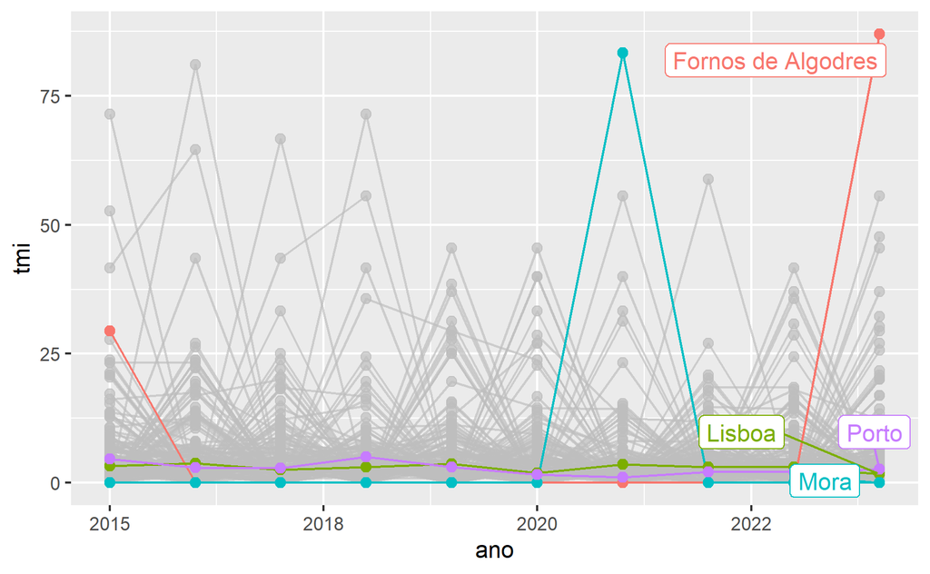

Em concelhos com mais população (e.g. Lisboa, Porto), a evolução das TMI não sugere tendência de aumento evidente.

Na tabela seguinte apresentam-se as TMI de acordo com o indice de privação (EDI).Quanto maior for o valor do indíce, maior o índice de privação. Para facilitar a leitura, agruparam-se previamente os concelhos de acordo com o valor EDI, da seguinte forma:

- Grupo 1, concelhos com valor EDI no 1º quintil (0-20),
- Grupo 2, concelhos com valor EDI no 2º quintil (20-40),
- Grupo 3, concelhos com valor EDI no 3º quintil (40-60),
- Grupo 4, concelhos com valor EDI no 4º quintil (60-80),
- Grupo 5, concelhos com valor EDI no 5º quintil (80-100).

Na tabela seguinte mostram-se as TMI médias obtidas em cada grupo e ano.

| EDI (Quintil) | 2015 | 2016 | 2017 | 2018 | 2019 | 2020 | 2021 | 2022 | 2023 | 2024 |
| --- | --- | --- | --- | --- | --- | --- | --- | --- | --- | --- |
| 1 | 3.26 | 3.92 | 2.11 | 1.73 | 3.19 | 3.108 | 0.714 | 1.32 | 2.564 | 2.16 |
| 2 | 2.59 | 3.16 | 2.50 | 1.42 | 1.35 | 2.854 | 2.312 | 2.58 | 4.011 | 3.38 |
| 3 | 3.24 | 2.97 | 3.65 | 4.40 | 3.06 | 0.783 | 2.621 | 2.51 | 0.736 | 4.27 |
| 4 | 2.82 | 4.24 | 2.75 | 2.13 | 3.36 | 2.623 | 3.707 | 3.08 | 1.964 | 4.16 |
| 5 | 3.79 | 2.37 | 2.33 | 3.66 | 3.12 | 3.206 | 1.676 | 2.08 | 3.237 | 2.06 |

### Análise do risco relativo

Para os modelos ajustados (M1-M7) apresentam-se na tabela seguinte os resultados obtidos com as medidas de ajustamento Deviance Information Criterion (DIC) e Watanabe-Akaike Information Criterion (WAIC), de modo a comparar o seu desempenho:

| Modelo | DIC | WAIC |
| --- | --- | --- |
| M1 | 4611 | 4612 |
| M2 | 4557 | 4563 |
| M3 | 4551 | 4554 |
| M4 | 4551 | 4554 |
| M5 | 4555 | 4561 |
| M6 | 4548 | 4551 |
| M7 | 4549 | 4551 |

Nesta tabela observa-se que os modelos M2-M7 apresentam melhor ajustamento que M1, o único que não inclui efeitos aleatórios espaciais. Observa-se ainda que a integração da covariável EDI melhora a qualidade do ajustamento quando se considera a componente temporal (estruturada e não-estruturada) conforme especificado em M6 e M7. A análise realizada sugere ainda que a inclusão de um termo de interação com o espaço (M7) não traz melhorias relevantes.

Embora o resultado dos últimos anos (2021-2024) aponte para um aumento da taxa de mortalidade infantil, O resultado do modelo M1 sugere uma tendência global de redução significativa do risco relativo ao longo periodo analisado de 2% ($\exp(\beta) \approx 0.98$). Na tabela seguinte apresentam-se algumas estatisticas sobre a distribuição à posteriori dos parâmetros em M1:

|  | mean | sd | 0.025quant | 0.5quant | 0.975quant |
| --- | --- | --- | --- | --- | --- |
| α | 0.099 | 0.044 | 0.013 | 0.099 | 0.186 |
| β | -0.018 | 0.007 | -0.033 | -0.018 | -0.004 |

No gráfico seguinte ilustra-se o impacto da tendência temporal linear global no RR, representada pela média da distribuição à posteriori de $\beta$ e respetivos limites inferior e superior para um IC95%.

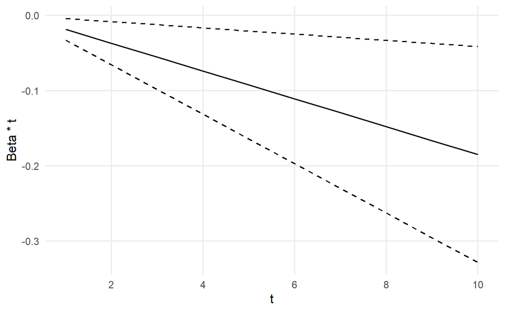

No modelo M2 explora-se o efeito aleatório das componentes espaço - $u_i+v_i$ - e dos efeitos global - $\beta$ - e local - $\delta_i$ - da componente tempo.

Os mapas seguintes ilustram as médias da distribuição à posteriori de $\zeta_i = \exp(u_i+v_i)$ (esq.) e de $\exp(\delta_i)$ (dir.).

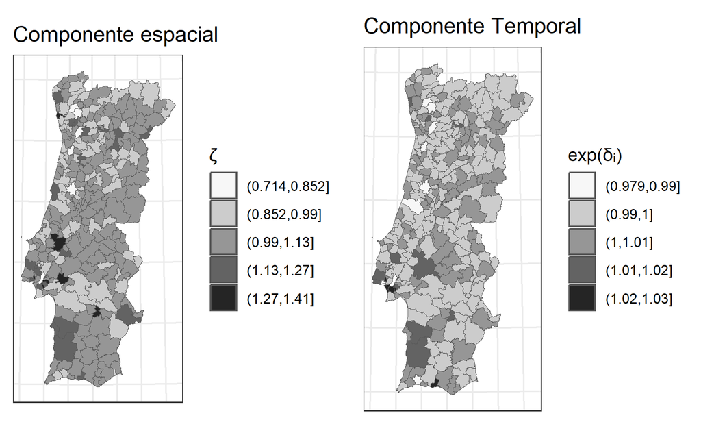

Médias da distribuição à posteriori para o efeito aleatório da componentes espacial (esq.) e para efeito do tempo em cada local (dir.)

No mapa de $\zeta$ (componente espacial) identifica-se uma tendência para os efeitos serem mais elevados na região de Lisboa e região Sul. Na distribuição de $\exp(\delta_i)$ identifica-se um aumento dos RR entre anos consecutivos mais acentuado em alguns concelhos destas regiões. Os mapas seguintes apresentam com mais detalhe os mapas de $\zeta$ e $\exp(\delta_i)$ para a região de Lisboa e Sul de Portugal.

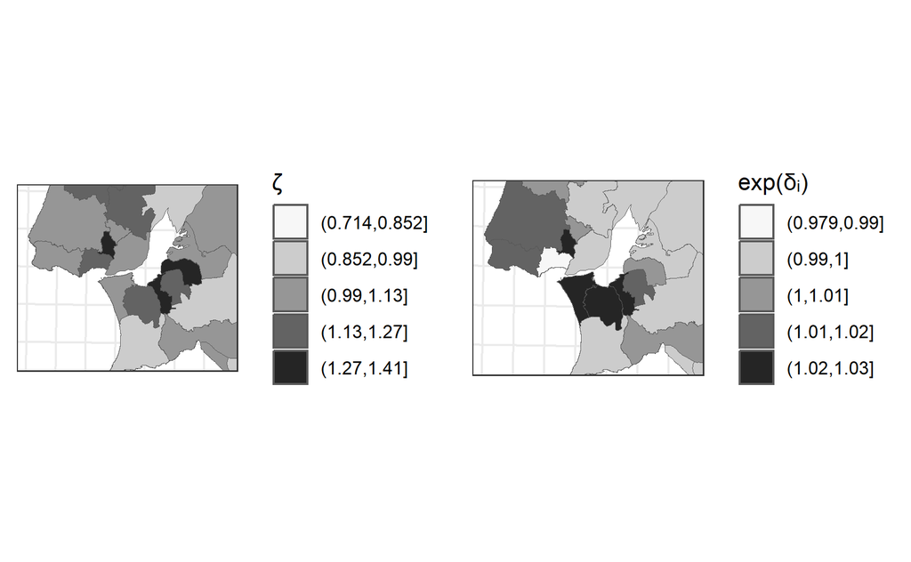

Por exemplo, a distribuição de $\exp(\delta_i)$ na região de Lisboa evidência tendências temporais de aumento dos RR mais acentuadas nos concelhos de Almada, Seixal, Barreiro e Amadora (todos a preto).

Dado que os modelos M2-M7 apresentaram resultados de ajustamento similares, nas secções seguintes vamos ver os resultados obtidos apenas para o que devolveu os melhores resultados: M6.

### Mapas do risco relativo (M6)

O padrão espaço-temporal das médias das distribuições à posteriori dos RR apresenta-se na figura seguinte:

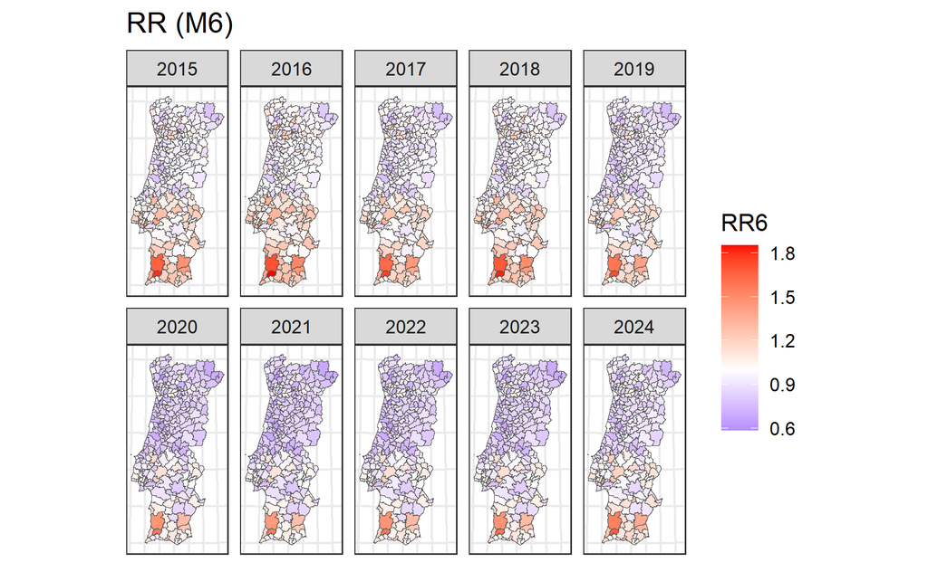

Distribuição à posteriori da média do RR por concelho 2015-2024, com M6

Em termo globais, os resultados obtidos até 2021 estão alinhados com os publicados para o periodo 2016-2021 por Nogueira et al[^5], que evidência o progresso notável na redução da TMI atingindo os valores mais baixos de sempre durante a pandemia da COVID-19. No entanto, a partir de 2021 observa-se um aumento generalizado do RR, ainda que com valores inferiores aos registados em 2015-2019.

A tabela seguinte contém as estimativas dos RR com IC95% por concelho/ano. Os concelhos/anos com RR significativamente superiores (a 1) estão pintados a rosa.

| cc | 2015 | 2016 | 2017 | 2018 | 2019 | 2020 | 2021 | 2022 | 2023 | 2024 |
| --- | --- | --- | --- | --- | --- | --- | --- | --- | --- | --- |
| Abrantes | 1.16 (0.80, 1.65) | 1.19 (0.83, 1.70) | 1.13 (0.79, 1.61) | 1.17 (0.81, 1.67) | 1.10 (0.77, 1.57) | 1.02 (0.70, 1.45) | 1.00 (0.69, 1.43) | 1.02 (0.71, 1.45) | 1.02 (0.71, 1.46) | 1.08 (0.74, 1.53) |
| Águeda | 0.91 (0.63, 1.28) | 0.94 (0.65, 1.32) | 0.89 (0.61, 1.25) | 0.92 (0.64, 1.30) | 0.87 (0.60, 1.22) | 0.80 (0.55, 1.12) | 0.79 (0.54, 1.11) | 0.80 (0.55, 1.13) | 0.81 (0.55, 1.13) | 0.85 (0.58, 1.19) |
| Aguiar da Beira | 0.90 (0.58, 1.32) | 0.93 (0.60, 1.36) | 0.88 (0.57, 1.29) | 0.91 (0.59, 1.34) | 0.86 (0.56, 1.26) | 0.79 (0.51, 1.17) | 0.78 (0.50, 1.15) | 0.80 (0.51, 1.17) | 0.80 (0.51, 1.17) | 0.84 (0.54, 1.23) |
| Alandroal | 1.14 (0.74, 1.66) | 1.18 (0.76, 1.71) | 1.12 (0.73, 1.62) | 1.16 (0.75, 1.69) | 1.09 (0.71, 1.58) | 1.01 (0.65, 1.46) | 0.99 (0.64, 1.44) | 1.01 (0.65, 1.47) | 1.01 (0.66, 1.47) | 1.06 (0.69, 1.55) |
| Albergaria-a-Velha | 1.01 (0.69, 1.45) | 1.04 (0.71, 1.49) | 0.99 (0.67, 1.41) | 1.02 (0.70, 1.47) | 0.96 (0.66, 1.38) | 0.89 (0.60, 1.27) | 0.88 (0.59, 1.25) | 0.89 (0.61, 1.28) | 0.89 (0.61, 1.28) | 0.94 (0.64, 1.35) |
| Albufeira | 1.40 (1.01, 1.91) | 1.44 (1.04, 1.97) | 1.37 (0.99, 1.87) | 1.42 (1.02, 1.94) | 1.34 (0.96, 1.82) | 1.23 (0.88, 1.69) | 1.21 (0.87, 1.66) | 1.24 (0.89, 1.69) | 1.24 (0.89, 1.69) | 1.30 (0.93, 1.78) |
| Alcácer do Sal | 1.02 (0.65, 1.49) | 1.05 (0.67, 1.54) | 1.00 (0.64, 1.45) | 1.04 (0.66, 1.51) | 0.98 (0.62, 1.42) | 0.90 (0.57, 1.31) | 0.89 (0.56, 1.29) | 0.90 (0.58, 1.32) | 0.90 (0.58, 1.32) | 0.95 (0.60, 1.39) |
| Alcanena | 0.96 (0.63, 1.40) | 0.99 (0.65, 1.45) | 0.94 (0.62, 1.37) | 0.98 (0.64, 1.42) | 0.92 (0.60, 1.34) | 0.85 (0.55, 1.24) | 0.83 (0.55, 1.22) | 0.85 (0.56, 1.24) | 0.85 (0.56, 1.24) | 0.89 (0.59, 1.31) |
| Alcobaça | 0.88 (0.60, 1.21) | 0.90 (0.62, 1.25) | 0.86 (0.59, 1.18) | 0.89 (0.61, 1.23) | 0.84 (0.58, 1.16) | 0.77 (0.53, 1.07) | 0.76 (0.52, 1.05) | 0.77 (0.53, 1.07) | 0.78 (0.53, 1.07) | 0.81 (0.56, 1.13) |
| Alcochete | 1.01 (0.66, 1.47) | 1.04 (0.68, 1.51) | 0.99 (0.65, 1.43) | 1.02 (0.67, 1.49) | 0.96 (0.63, 1.40) | 0.89 (0.58, 1.29) | 0.87 (0.57, 1.27) | 0.89 (0.58, 1.29) | 0.89 (0.59, 1.30) | 0.94 (0.61, 1.37) |
| Alcoutim | 1.42 (0.87, 2.14) | 1.46 (0.90, 2.21) | 1.38 (0.86, 2.09) | 1.44 (0.89, 2.18) | 1.35 (0.84, 2.04) | 1.25 (0.77, 1.89) | 1.23 (0.76, 1.86) | 1.25 (0.77, 1.89) | 1.25 (0.77, 1.90) | 1.32 (0.81, 2.00) |
| Alenquer | 1.12 (0.79, 1.55) | 1.15 (0.81, 1.60) | 1.09 (0.77, 1.51) | 1.13 (0.80, 1.57) | 1.07 (0.75, 1.48) | 0.98 (0.69, 1.37) | 0.97 (0.68, 1.34) | 0.99 (0.70, 1.37) | 0.99 (0.70, 1.37) | 1.04 (0.73, 1.44) |
| Alfândega da Fé | 0.97 (0.64, 1.43) | 1.00 (0.66, 1.48) | 0.95 (0.63, 1.40) | 0.98 (0.65, 1.45) | 0.92 (0.61, 1.37) | 0.85 (0.56, 1.26) | 0.84 (0.55, 1.24) | 0.86 (0.56, 1.26) | 0.86 (0.56, 1.27) | 0.90 (0.59, 1.33) |
| Alijó | 0.99 (0.64, 1.43) | 1.02 (0.66, 1.48) | 0.96 (0.63, 1.40) | 1.00 (0.65, 1.45) | 0.94 (0.62, 1.37) | 0.87 (0.57, 1.26) | 0.85 (0.56, 1.24) | 0.87 (0.57, 1.26) | 0.87 (0.57, 1.27) | 0.92 (0.60, 1.33) |
| Aljezur | 1.35 (0.86, 2.00) | 1.39 (0.89, 2.06) | 1.32 (0.85, 1.96) | 1.37 (0.88, 2.03) | 1.29 (0.83, 1.91) | 1.19 (0.76, 1.76) | 1.17 (0.75, 1.74) | 1.19 (0.76, 1.77) | 1.20 (0.77, 1.77) | 1.26 (0.80, 1.87) |
| Aljustrel | 1.08 (0.70, 1.63) | 1.11 (0.72, 1.68) | 1.06 (0.69, 1.59) | 1.10 (0.71, 1.65) | 1.03 (0.67, 1.55) | 0.95 (0.62, 1.43) | 0.94 (0.61, 1.41) | 0.96 (0.62, 1.44) | 0.96 (0.62, 1.44) | 1.01 (0.65, 1.52) |
| Almada | 1.25 (0.98, 1.58) | 1.29 (1.02, 1.63) | 1.23 (0.97, 1.54) | 1.27 (1.00, 1.60) | 1.20 (0.95, 1.50) | 1.10 (0.86, 1.39) | 1.09 (0.85, 1.37) | 1.11 (0.87, 1.39) | 1.11 (0.87, 1.40) | 1.17 (0.91, 1.47) |
| Almeida | 0.90 (0.58, 1.32) | 0.93 (0.60, 1.36) | 0.88 (0.57, 1.29) | 0.91 (0.59, 1.34) | 0.86 (0.55, 1.26) | 0.79 (0.51, 1.17) | 0.78 (0.50, 1.15) | 0.79 (0.51, 1.17) | 0.80 (0.51, 1.17) | 0.83 (0.54, 1.23) |
| Almeirim | 1.20 (0.82, 1.76) | 1.24 (0.85, 1.81) | 1.18 (0.81, 1.72) | 1.22 (0.84, 1.79) | 1.15 (0.79, 1.68) | 1.06 (0.72, 1.55) | 1.04 (0.71, 1.53) | 1.06 (0.73, 1.55) | 1.07 (0.73, 1.56) | 1.12 (0.76, 1.64) |
| Almodôvar | 1.20 (0.78, 1.76) | 1.24 (0.80, 1.82) | 1.18 (0.76, 1.72) | 1.22 (0.79, 1.79) | 1.15 (0.74, 1.68) | 1.06 (0.68, 1.55) | 1.04 (0.67, 1.53) | 1.06 (0.69, 1.56) | 1.07 (0.69, 1.56) | 1.12 (0.72, 1.64) |
| Alpiarça | 1.02 (0.67, 1.51) | 1.05 (0.70, 1.56) | 1.00 (0.66, 1.47) | 1.04 (0.68, 1.53) | 0.98 (0.65, 1.44) | 0.90 (0.59, 1.33) | 0.89 (0.58, 1.31) | 0.90 (0.60, 1.33) | 0.91 (0.60, 1.34) | 0.95 (0.63, 1.41) |
| Alter do Chão | 1.06 (0.68, 1.55) | 1.09 (0.70, 1.60) | 1.03 (0.67, 1.51) | 1.07 (0.69, 1.57) | 1.01 (0.65, 1.48) | 0.93 (0.60, 1.37) | 0.92 (0.59, 1.35) | 0.93 (0.60, 1.37) | 0.94 (0.60, 1.37) | 0.98 (0.63, 1.44) |
| Alvaiázere | 0.93 (0.58, 1.40) | 0.96 (0.60, 1.44) | 0.91 (0.57, 1.37) | 0.95 (0.59, 1.42) | 0.89 (0.56, 1.33) | 0.82 (0.51, 1.23) | 0.81 (0.51, 1.21) | 0.82 (0.52, 1.23) | 0.83 (0.52, 1.24) | 0.87 (0.54, 1.30) |
| Alvito | 1.09 (0.72, 1.60) | 1.13 (0.74, 1.65) | 1.07 (0.70, 1.56) | 1.11 (0.73, 1.62) | 1.04 (0.69, 1.52) | 0.96 (0.63, 1.41) | 0.95 (0.62, 1.39) | 0.97 (0.63, 1.41) | 0.97 (0.63, 1.41) | 1.02 (0.66, 1.49) |
| Amadora | 1.58 (1.27, 1.94) | 1.62 (1.31, 2.00) | 1.54 (1.25, 1.89) | 1.60 (1.29, 1.97) | 1.50 (1.22, 1.85) | 1.39 (1.11, 1.71) | 1.37 (1.09, 1.68) | 1.39 (1.12, 1.71) | 1.40 (1.12, 1.71) | 1.46 (1.18, 1.81) |
| Amarante | 0.94 (0.63, 1.30) | 0.96 (0.65, 1.34) | 0.92 (0.62, 1.27) | 0.95 (0.64, 1.32) | 0.89 (0.61, 1.24) | 0.82 (0.56, 1.14) | 0.81 (0.55, 1.13) | 0.83 (0.56, 1.15) | 0.83 (0.56, 1.15) | 0.87 (0.59, 1.21) |
| Amares | 0.95 (0.64, 1.38) | 0.98 (0.66, 1.42) | 0.93 (0.63, 1.34) | 0.97 (0.65, 1.40) | 0.91 (0.61, 1.31) | 0.84 (0.56, 1.21) | 0.83 (0.55, 1.20) | 0.84 (0.57, 1.22) | 0.85 (0.57, 1.22) | 0.89 (0.59, 1.28) |
| Anadia | 0.98 (0.66, 1.44) | 1.01 (0.68, 1.48) | 0.96 (0.65, 1.40) | 1.00 (0.67, 1.46) | 0.94 (0.63, 1.37) | 0.86 (0.58, 1.26) | 0.85 (0.57, 1.25) | 0.87 (0.58, 1.27) | 0.87 (0.58, 1.27) | 0.91 (0.61, 1.34) |
| Ansião | 0.93 (0.61, 1.37) | 0.96 (0.63, 1.41) | 0.91 (0.60, 1.33) | 0.94 (0.62, 1.39) | 0.89 (0.58, 1.30) | 0.82 (0.54, 1.20) | 0.81 (0.53, 1.18) | 0.82 (0.54, 1.21) | 0.82 (0.54, 1.21) | 0.87 (0.57, 1.27) |
| Arcos de Valdevez | 0.99 (0.65, 1.42) | 1.02 (0.67, 1.47) | 0.97 (0.64, 1.39) | 1.01 (0.66, 1.44) | 0.95 (0.62, 1.36) | 0.88 (0.57, 1.25) | 0.86 (0.56, 1.23) | 0.88 (0.58, 1.26) | 0.88 (0.58, 1.26) | 0.92 (0.60, 1.33) |

[output cut: 248 more lines]

Em relação à covariável EDI considerada em M6, os resultados da análise indicam que o aumento do indice de privação sugere um aumento significativo no RR de mortalidade infantil 3.71% (IC 95%:1.5, 5.9%).

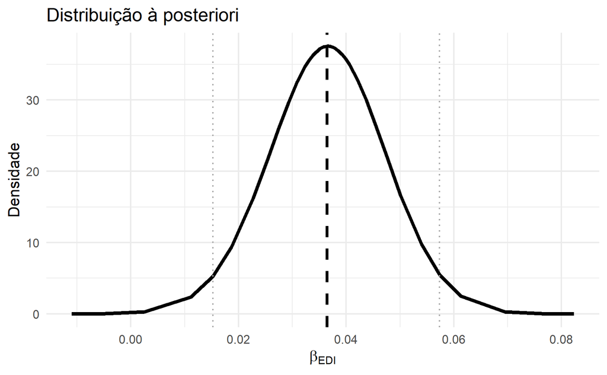

### RR 2024

Nesta secção apresentam-se os resultados para 2024 com mais detalhe. Em particular apresenta-se um gráfico de barras com as estimativas do RR em cada concelho e o respectivo IC95%. As barras dos concelhos com RR significativamente superiores (a 1) estão pintadas a vermelho.

Nesta secção ilustram-se também os padrões espaciais com os mapas de RR e IC95% para 1) Portugal, 2) região de Lisboa e 3) região Sul.

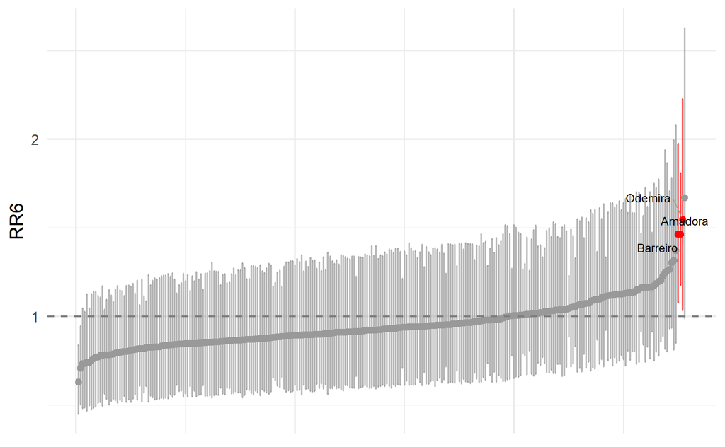

Vejamos agora os padrões espaciais do RR em Portugal, ampliando depois o mapa para visualizar com mais detalhe as regiões de Lisboa (que inclui concelhos densamente povoados) e a região do Sul. A par dos mapas de RR apresentam-se os mapas dos limites inferior (LInf) e superior (LSup) do IC95%.

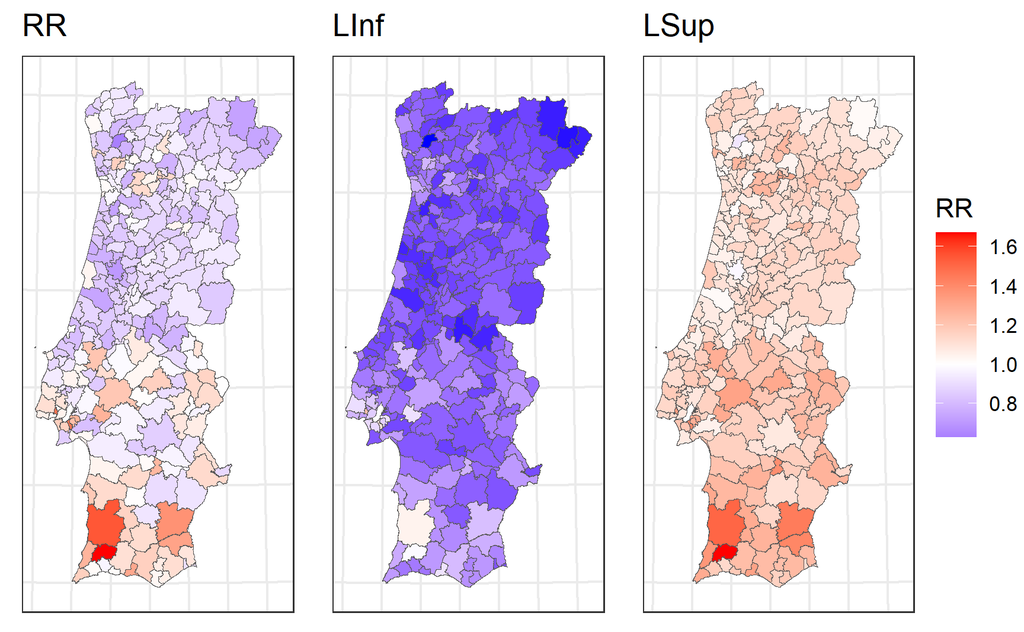

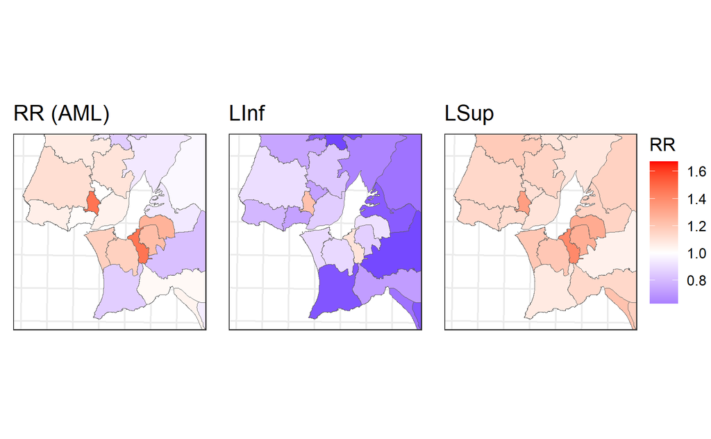

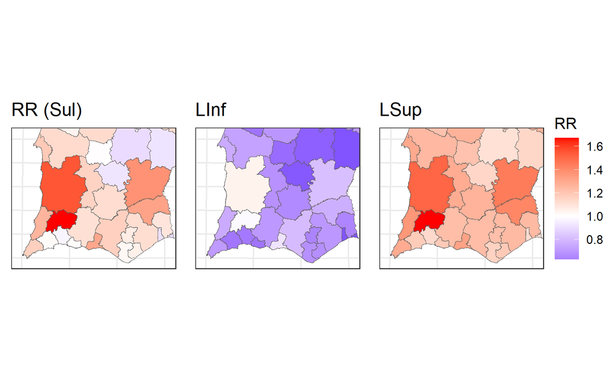

[^1]: https://doi.org/10.1371/journal.pone.0208320
[^2]: https://www.dgterritorio.gov.pt/cartografia/cartografia-tematica/caop
[^3]: https://doi.org/10.1111/j.1467-9868.2008.00700.x
[^4]: https://www.pordata.pt/pt/estatisticas/populacao/esperanca-de-vida-e-obitos/taxa-de-mortalidade-infantil-0
[^5]: https://doi.org/10.20344/amp.19642